# Consulting Project

### Background

The Golden State Warriors won the 2022 NBA championship. Their style of play has been said to have revolutionized all of basketball due to their impressive 3-point shooting with players like Stephen Curry and Klay Thompson. Claims as such may lead one to question how impactful is their 3-point shooting on their wins? Can the amount of 3 pointers the Warriors made in a game be a good predictor of whether or not they won the game. Using statistical models we can answer this question.

### Analysis

The probability of the Warriors winning the game is given by the following logistic regression model.

$$P(Y_i = 1|\, x_i) = \frac{e^{\beta_0 + \beta_1 x_i}}{1+e^{\beta_0 +
\beta_1 x_i}} = \pi_i$$

In this model, for each measurement i:

$$\text {- } Y_i = \text{ 1 indicates that the warriors won the game}$$

$$\text {- } Y_i = \text{ 0 denotes that the Warriors lost the game}$$

$$\text {- } x_i \text{ denotes the amount of 3 pointers made in the
game}$$
$$e^{\beta_1} \text{ can be interpreted as the proportional change in the
odds that the Warriors win the game (Yi=1) for every increase in
3-pointer made}$$
$$e^{\beta_0} \text{ represents the y-intercept or the probability of the
Warriors winning the game with 0 3-pointeres made.}$$

### Hypothesis

If β1 is zero in the above model, then xi (3 pointers made) provides no insight about the probability of the Warriors winning the game. If not zero however, then amount of 3 pointers made plays an important role in the probability of the Warriors winning the game. Using a significance level of α=0.05 we will test the below hypotheses about β1.

$$H_0: \beta_1 = 0$$

$$H_a: \beta_1 \ne 0$$

### Test

```r
wars.glm <- glm( WinsLosses == 'W'~ ThreesMade, data=data, family=binomial)
summary(wars.glm) %>% pander::pander()
```

|  | Estimate | Std. Error | z value | Pr(>\|z\|) |
| --- | --- | --- | --- | --- |
| **(Intercept)** | -1.82 | 0.9897 | -1.839 | 0.06592 |
| **ThreesMade** | 0.1383 | 0.07202 | 1.92 | 0.05481 |

(Dispersion parameter for binomial family taken to be 1 )

| Null deviance: | 69.31 on 49 degrees of freedom |
| --- | --- |
| Residual deviance: | 65.24 on 48 degrees of freedom |

The test gives us the equation

$$P(Y_i = 1|\, x_i) = \frac{e^{ -1.82 + 0.1383 x_i}}{1+e^{-1.82 + 0.1383
x_i}} = \pi_i$$

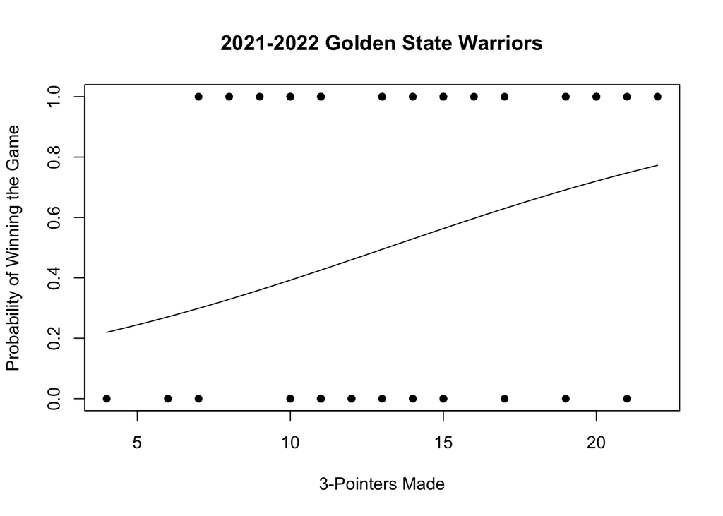

```r
plot( WinsLosses == 'W' ~ ThreesMade, data=data, xlab="3-Pointers Made", ylab='Probability of Winning the Game', pch=16, main="2021-2022 Golden State Warriors")

#Getting the coeffiencts
b <- coef(wars.glm)
curve(exp(b[1]+b[2]*x)/(1+exp(b[1]+b[2]*x)), add=TRUE)
```

### Checking Model Assumptions

Because not all xi values are replicated many times, we must use the Hosmer-Lemeshow Test. With a level of significance = .05. Our null hypothesis, in this case, is that our data is accpetable. If we get a p-value less than .05 then we will reject this null hypothesis.

```r
hoslem.test(wars.glm$y, wars.glm$fitted, g=10) %>% pander::pander()
```

Hosmer and Lemeshow goodness of fit (GOF) test: `wars.glm$y, wars.glm$fitted`

| Test statistic | df | P value |
| --- | --- | --- |
| 5.451 | 8 | 0.7085 |

We have a p-value of .7085 so we will fail to reject the null that a logistic regression is a good fit for our data and say that the requirements for a logistic regression with this data are met.

### Conclusion

The results of our test show that there really isn’t a strong link between the amount of three pointers made and if the game was won or not. This ultimately shows that anyone who believes that the Warriors are only a three-point shooting team, does not give the Warriors enough credit for how good and well-rounded that they really are. This ultimately tells us that there were many other factors and things that the warriors did to win their games. Future analysis would be helpful when analyzing other statistics that most strongly led to the Warriors winning their games. Some of these could even be scoring from individual players on the team like Stephen Curry or even the impact some of the players may have had off the bench.